# Desafio 5: Análises Avançados de Tipos de Dados Diversos

O prazo para entregar Desafio 5 por email com título “[FLS6397] - D5” à minha conta é **22/07/2021**. Por favor entregue (i) o arquivo .Rmd (ou .Rnw se preferir), e (ii) o arquivo .html ou .PDF.

## Instruções

Siga as instruções abaixo. Documente *todos* os seus passos em um script. Comente no seu script *todos* os seus passos e explique a si mesma(o) suas escolhas e estratégias. Se você se beneficiou da assistência de outra pessoa, sempre reconheça isso em comentários no código.

## Roteiro

**Análise Espacial**

1. Instale e abra [o pacote `geobr` do IBGE](https://github.com/ipeaGIT/geobr). Leia as instruções no site de github sobre o pacote e use a função `read_municipality()` para acessar todos os municípios do estado de São Paulo em 2018.

```r
# install.packages("geobr")
library("tidyverse")
library("sf")
library("geobr")
library("rmarkdown")
library("knitr")

muns_SP <- read_municipality(code_muni="SP", year=2018)
```

2. Use a funcionalidade da família de `map` para aplicar a função `read_municipality` para os seguintes cinco estados seguintes em uma única linha de código: SP, RJ, MT, RS e RN (todos para o ano de 2018).

```r
estados <- c("SP", "RJ", "MT", "RS", "RN")

muns_estados <- estados %>% map(read_municipality, year=2018)
```

3. Baixe, descompacte e abre em R o arquivo da população paulista por município em 2010 [do site do IBGE](https://www.ibge.gov.br/estatisticas/downloads-estatisticas.html), clicando em ‘Censos’ -> ‘Censo_Demografico_2010’ -> ‘resultados’ -> ‘total_populacao_sao_paulo.zip’.

```r
library("readxl")

popn_sp <- read_excel("total_populacao_sao_paulo/total_populacao_sao_paulo.xls") %>% slice(-((n()-1):n()))

# obs: As duas últimas linhas na planilha contém dados de resumo que não são observações:
#o total do estado e o link do site do IBGE de onde a planilha foi tirada.
#Idealmente, devemos tirar elas, mas por sorte provavalmente eles estarão tirados com o left_join na próxima questão.
```

4. Queremos mapear dados da população por município. Identifique a chave apropriada, e cruze o banco da população com o banco das fronteiras dos municípios de SP.

```r
popn_sp <- popn_sp %>% mutate(code_muni=as.numeric(`Código do município`))

muns_SP <- muns_SP %>% left_join(popn_sp, by="code_muni")
```

5. Usando o seu banco de dados de Questão 4, calcule a proporção da população urbana na população total em cada município e apresente os seus resultados por meio de um mapa bem-formatado dessa taxa por município em 2010. Aplique uma escala de cores e formatação apropriada.

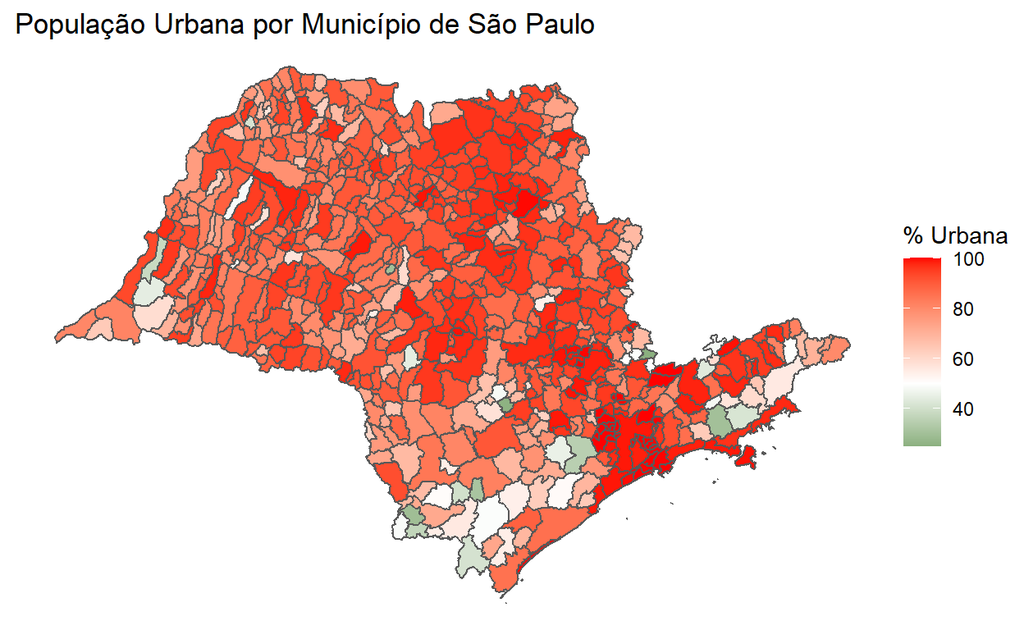

```r
muns_SP <- muns_SP %>% mutate(taxa_urbana=100*(`Total da população urbana`/`Total da população 2010`))

muns_SP %>%
  ggplot() +
  geom_sf(aes(fill=taxa_urbana)) +
  scale_fill_gradient2(name="% Urbana", low="dark green", mid="white", high="red", midpoint=50) +
  theme_void() +
  ggtitle("População Urbana por Município de São Paulo")
```

**Testes Estatísticos e Regressões**

6. Usando o banco de dados de Questão 5, faça um teste de shapiro para avaliar se a taxa de urbanização dos municípios de SP é distribuída de forma normal.

```r
muns_SP %>% pull(taxa_urbana) %>% shapiro.test()
```

```
    Shapiro-Wilk normality test

data:  .
W = 0.86591, p-value < 2.2e-16
```

7. Usando os mesmos dados de SP, execute uma regressão linear para avaliar se a taxa de urbanização dos municípios (a variável dependente) é associada com a população total do município (a variável independente). Ou seja, se maiores municípios são mais urbanizados. Apresente o resultado numa tabela de regressão bem-formatada.

```r
library("stargazer")

muns_SP %>% lm(taxa_urbana ~  + `Total da população 2010`, data=.)  %>%
  stargazer(type="html", title="Preditores da Taxa Urbana por Município")
```

**Preditores da Taxa Urbana por Município**

|  | *Dependent variable:* |
| --- | --- |
|  | taxa_urbana |
| `Total da população 2010` | 0.00000*** |
|  | (0.00000) |
| Constant | 84.034*** |
|  | (0.565) |
| Observations | 645 |
| R<sup>2</sup> | 0.013 |
| Adjusted R<sup>2</sup> | 0.012 |
| Residual Std. Error | 14.214 (df = 643) |
| F Statistic | 8.558*** (df = 1; 643) |
| *Note:* | p<0.1; p<0.05; p<0.01 |

8. Mostre um gráfico do efeito marginal (o coeficiente) da variável da população na regressão da questão anterior em Questão 8 e o intervalo de confiança do coeficiente.

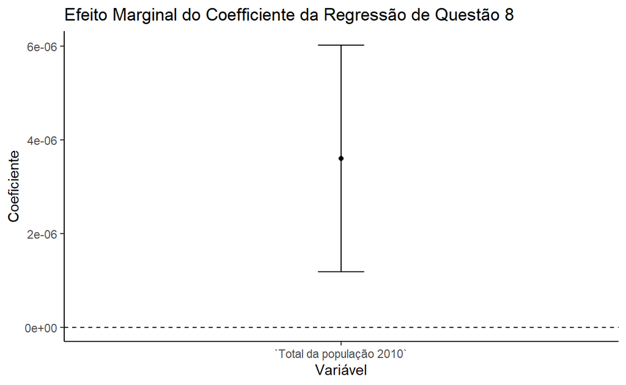

```r
library("broom")
muns_SP %>% lm(taxa_urbana ~  + `Total da população 2010`, data=.) %>%
  tidy() %>%
  mutate(conf.lo=estimate-1.96*std.error,
         conf.hi=estimate+1.96*std.error) %>%
  filter(term!="(Intercept)") %>%
  ggplot() +
  geom_point(aes(x=term, y=estimate)) +
  geom_errorbar(aes(x=term, y=estimate, ymin=conf.lo, ymax=conf.hi), width=0.1) +
  geom_hline(yintercept=0, lty=2) +
  theme_classic() +
  ggtitle("Efeito Marginal do Coefficiente da Regressão de Questão 8") +
  xlab("Variável") +
  ylab("Coeficiente")
```